# Section 4: Content analyses

*Note: the analyses in this notebook expect certain files to have already been created by the preprocessing.Rmd and structure.ipynb notebooks*

# Import data

```r
library(tidyverse)
library(lme4)
library(lmerTest)
library(ggthemes)
library(tm)
library(tidyboot)
library(xtable)
library(entropy)
library(useful)
library(viridis)
library(broom.mixed)
library(gganimate)
library(modeest)
library(knitr)

source('../utils/analysis_helpers.R')
```

# Section 4 | RESULTS: CHARACTERIZING THE DYNAMICS OF SEMANTIC CONTENT

```r
# All analyses reported on sequential cued version of task
d <- read_csv('../../data/tangramsSequential_collapsed.csv', col_types = 'ciiccil')
```

## Section 4.1: Initially distinctive words are more likely to conventionalize

```r
distinctiveness_d_raw <- read.csv("../outputs/PMI.csv", header = TRUE) %>%
  mutate(finalRoundMatch = ifelse(finalRoundMatch == 'True', 1, 0)) %>%
  filter(!is.na(tf.idf)) %>%
  mutate(num_tangrams_occurred_with = ifelse(tf.idf == 0, 0, round(1 / ((2^tf.idf) /12))) )

# exclude words that didn't appear on first round
distinctiveness_d <- distinctiveness_d_raw %>%
  filter(num_tangrams_occurred_with > 0 )
```

look at how often final round occurred on early round (noted in main text)

```r
distinctiveness_d_raw %>%
  mutate(occuredOnFirstRound = num_tangrams_occurred_with > 0) %>%
  group_by(finalRoundMatch, occuredOnFirstRound) %>%
  tally() %>%
  filter(finalRoundMatch == 1) %>%
  spread(occuredOnFirstRound,n) %>%
  mutate(proportionOfMatchesInInitialRound = `TRUE`/(`TRUE`+`FALSE`)) %>%
  pull(proportionOfMatchesInInitialRound)
```

```
## [1] 0.5660435
```

stats

```r
distinctiveness_d %>%
  glmer(finalRoundMatch ~ num_tangrams_occurred_with +
            (1 + num_tangrams_occurred_with | intendedName) +
            (1 + num_tangrams_occurred_with | gameid),
        family = 'binomial',
        control = glmerControl(optCtrl = list(maxfun = 200000)),
        data = .) %>%
  tidy()
```

| effect | group | term | estimate | std.error | statistic | p.value |
| --- | --- | --- | --- | --- | --- | --- |
| fixed | NA | (Intercept) | -1.14037801 | 0.13544599 | -8.419430 | 3.783214e-17 |
| fixed | NA | num_tangrams_occurred_with | -0.22929200 | 0.03783046 | -6.061041 | 1.352432e-09 |
| ran_pars | gameid | sd__(Intercept) | 0.64940037 | NA | NA | NA |
| ran_pars | gameid | cor__(Intercept).num_tangrams_occurred_with | -0.25127302 | NA | NA | NA |
| ran_pars | gameid | sd__num_tangrams_occurred_with | 0.19554353 | NA | NA | NA |
| ran_pars | intendedName | sd__(Intercept) | 0.36198622 | NA | NA | NA |
| ran_pars | intendedName | cor__(Intercept).num_tangrams_occurred_with | -0.97148828 | NA | NA | NA |
| ran_pars | intendedName | sd__num_tangrams_occurred_with | 0.09167012 | NA | NA | NA |

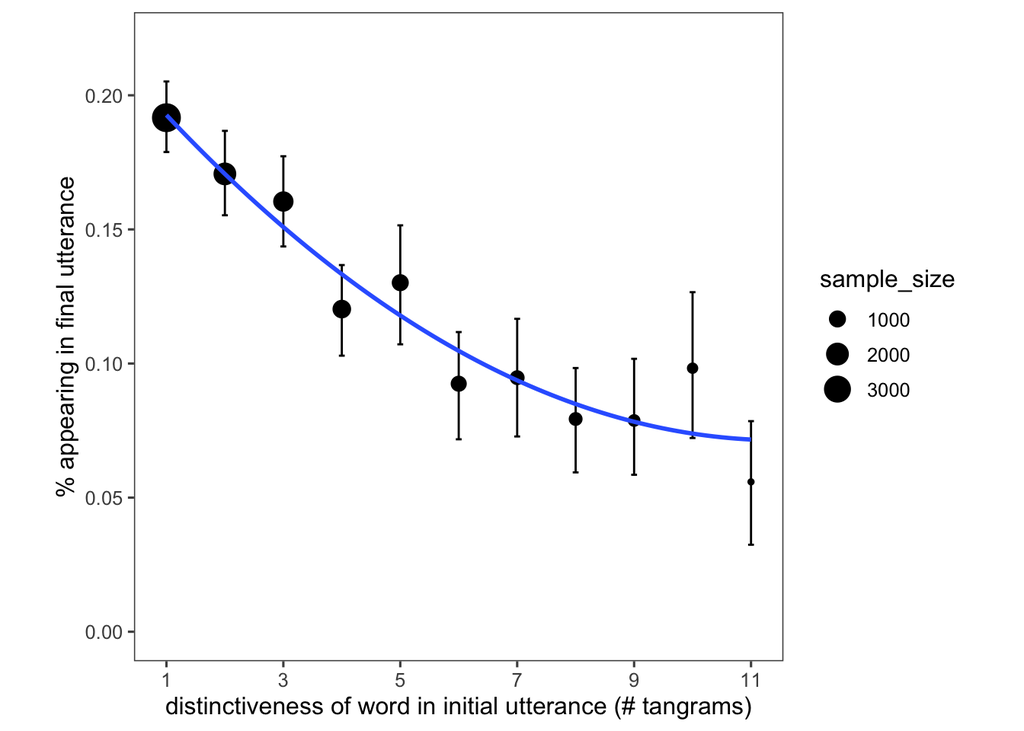

```r
distinctiveness_d %>%
  group_by(num_tangrams_occurred_with) %>%
  tidyboot_mean(finalRoundMatch,nboot = 500) %>%
  rename(sample_size = n) %>%
  ggplot(aes(x = as.integer(num_tangrams_occurred_with), y =empirical_stat)) +
    geom_point(aes(size = sample_size), stat = 'identity') +
    geom_errorbar(aes(ymin = ci_lower, ymax = ci_upper), width = 0.1) +
    geom_smooth(method = 'lm', formula = y ~ poly(x, 2), se = F) +
    ylim(0, .22) +
    ylab('% appearing in final utterance') +
    xlab('distinctiveness of word in initial utterance (# tangrams)') +
    xlim(0,12) +
    scale_x_continuous(breaks = c(1,3, 5,7,9,11))+
    theme_few() +
    theme(aspect.ratio = 1)
```

```r
ggsave('../../writing/figs/distinctiveness.pdf',  height = 7, width = 10, units = 'cm', useDingbats = F)
```

Alternatively, we can do a nonparametric analysis. Draw a random word from each tangram/gameid pair and look at the percentage that match with round 6. This gives a null distribution. Then we can take the highest PMI word (or words) for each tangram/gameid pair and look at the percentage of *those* that match. We see that it’s much higher than expected under the null.

```r
nonparametric_ds = seq_len(1000) %>%
  map_dbl(~ { distinctiveness_d %>%
    group_by(intendedName, gameid) %>%
    sample_n(1) %>%
      ungroup() %>%
      summarize(m = mean(finalRoundMatch)) %>%
      pull(m)})

highest <- seq_len(1000) %>%
  map_dbl(~ { distinctiveness_d %>%
    group_by(intendedName, gameid) %>%
    filter(num_tangrams_occurred_with == min(num_tangrams_occurred_with)) %>%
    sample_n(1) %>%
    ungroup() %>%
    summarize(m = mean(finalRoundMatch)) %>%
    pull(m)})

cat('range for permuted=', sort(nonparametric_ds)[1], sort(nonparametric_ds)[1000])
```

```
## range for permuted= 0.1634712 0.2330979
```

```r
cat('range for highest=', sort(highest)[1], sort(highest)[1000])
```

```
## range for highest= 0.2441978 0.3037336
```

## Section 4.2: Semantic meaning diverges across pairs and stabilizes within pairs

```r
M_mat = read_csv('../outputs/meta_tangrams_embeddings.csv',
                 col_types = "nccnlc", na = c('[nan]')) %>%
  # need to correct for R's (terrible) 1-indexing...
  mutate(feature_ind = X1 + 1,
         gameID = gameid,
         target = intendedName,
         repetition = as.numeric(repetitionNum)) #%>%
```

### Utterances are more similar overall within games than between games

```r
load('F_mat_raw.Rdata')
combined.df <- compute_within_vs_across(M_mat, F_mat)

true_dprime = dprime(combined.df)

permuted_dprimes <- seq_len(1000) %>%
  map_dbl(~ dprime(combined.df %>% mutate(source = sample(source))))

cat('CI for permuted=', sort(permuted_dprimes)[25], sort(permuted_dprimes)[975])
```

```
## CI for permuted= -0.08759046 0.09225413
```

```r
cat('true=', true_dprime)
```

```
## true= -2.645725
```

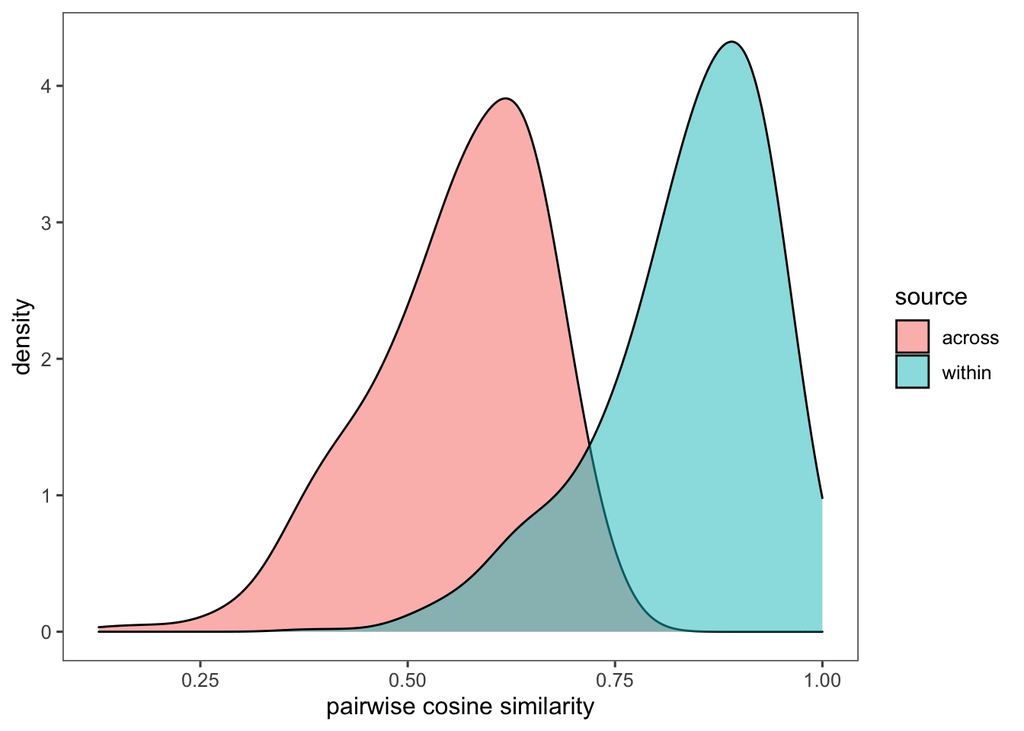

```r
combined.df %>%
  ggplot(aes(x = empirical_stat, fill = source)) +
    geom_density(adjust = 1.5, alpha = .5) +
    xlab('pairwise cosine similarity') +
    theme_few()
```

```r
ggsave('../../writing/figs/across_vs_within.pdf',
       height = 7, width = 10, units = 'cm', useDingbats = F)
```

### Utterances become increasingly consistent within interaction

Stats

```r
true_lmer.within <- make_within_df(M_mat, F_mat, 'cosine') %>%
  filter(rep2 == rep1 + 1) %>%
  ungroup()

library(optimx)
true_lmer.within %>%
  lmer(sim ~ poly(rep1, 2) +
         (1 + poly(rep1, 2) | gameID) +
         (1 + poly(rep1, 2) | target),
       control = lmerControl(optimizer ='optimx',
                             optCtrl=list(method='nlminb')),
       data = .) %>%
  tidy()
```

| effect | group | term | estimate | std.error | statistic | df | p.value |
| --- | --- | --- | --- | --- | --- | --- | --- |
| fixed | NA | (Intercept) | 0.90074475 | 0.004791451 | 187.989961 | 29.62951 | 3.792600e-47 |
| fixed | NA | poly(rep1, 2)1 | 2.82879357 | 0.256706210 | 11.019576 | 35.48558 | 5.262001e-13 |
| fixed | NA | poly(rep1, 2)2 | -0.44273419 | 0.202156285 | -2.190059 | 35.69191 | 3.513928e-02 |
| ran_pars | gameID | sd__(Intercept) | 0.02845593 | NA | NA | NA | NA |
| ran_pars | gameID | cor__(Intercept).poly(rep1, 2)1 | -0.08881040 | NA | NA | NA | NA |
| ran_pars | gameID | cor__(Intercept).poly(rep1, 2)2 | -0.38847950 | NA | NA | NA | NA |
| ran_pars | gameID | sd__poly(rep1, 2)1 | 1.66389746 | NA | NA | NA | NA |
| ran_pars | gameID | cor__poly(rep1, 2)1.poly(rep1, 2)2 | -0.39042969 | NA | NA | NA | NA |
| ran_pars | gameID | sd__poly(rep1, 2)2 | 1.21095964 | NA | NA | NA | NA |
| ran_pars | target | sd__(Intercept) | 0.01108323 | NA | NA | NA | NA |

[output cut: 6 more lines]

Viz

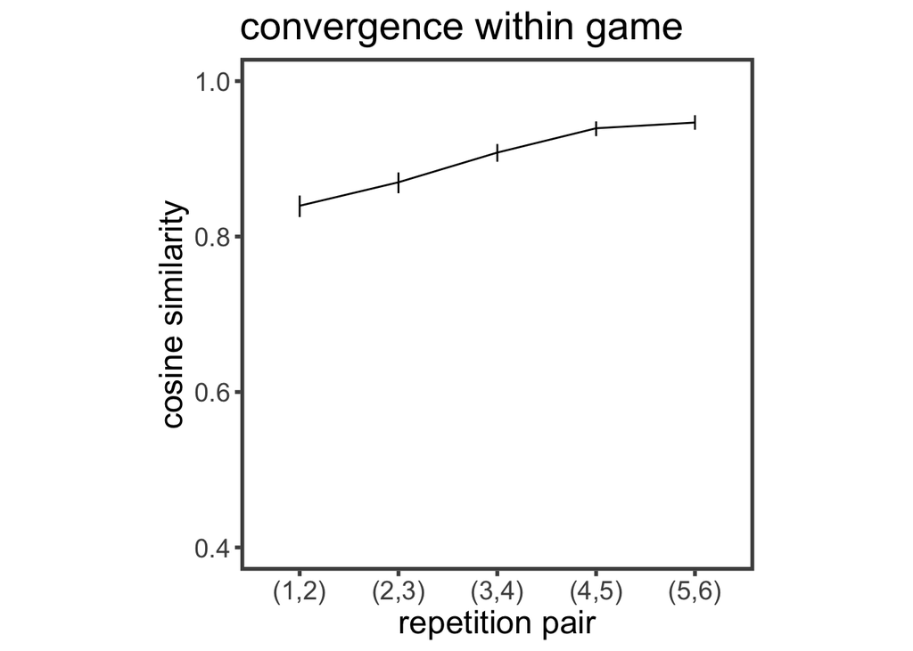

```r
true_lmer.within.toplot <- true_lmer.within %>%
  group_by(gameID, rep1) %>%
  summarize(m = mean(sim,na.rm=T)) %>%
  group_by(rep1) %>%
  tidyboot_mean(m, na.rm=T)
true_lmer.within.toplot %>%
  ggplot(aes(x = as.character(rep1), y = empirical_stat, group = 1)) +
    geom_errorbar(aes(ymin = ci_lower, ymax = ci_upper), width = 0) +
    geom_line()  +
    scale_x_discrete(labels = c('(1,2)','(2,3)', '(3,4)', '(4,5)', '(5,6)' )) +
    ylim(0.4, 1) +
    ylab('cosine similarity') +
    ggtitle('convergence within game') +
    theme_few() +
    xlab('repetition pair') +
    guides(color = F, fill = F) +
    theme(aspect.ratio = 1, legend.position = c(0.6, 0.5), text = element_text(size=18),
          element_line(size=1), element_rect(size=2, color="#00000"))
```

```r
ggsave('../../writing/figs/stability_mean.pdf',
       height = 10, width = 10, units = 'cm', useDingbats = F)
```

### Utterances become increasingly different across interactions

Stats

```r
true_lmer.across <- M_mat %>%
   group_by(target, repetition) %>%
   do(flatten_sim_matrix(get_sim_matrix(., F_mat, method = 'cosine'), .$gameID)) %>%
  ungroup() %>%
  mutate(target = factor(target))

true_lmer.across %>%
  lmer(sim ~ poly(repetition, 2) + (1 +poly(repetition, 2)  | target),
       control = lmerControl(optimizer ='optimx',
                             optCtrl=list(method='nlminb')),
       data = .) %>%
  tidy()
```

| effect | group | term | estimate | std.error | statistic | df | p.value |
| --- | --- | --- | --- | --- | --- | --- | --- |
| fixed | NA | (Intercept) | 0.57224816 | 0.01440592 | 39.72314 | 11.00048 | 3.117639e-13 |
| fixed | NA | poly(repetition, 2)1 | -48.60609413 | 2.91104940 | -16.69710 | 11.00024 | 3.668841e-09 |
| fixed | NA | poly(repetition, 2)2 | 15.26890174 | 1.40181322 | 10.89225 | 11.00042 | 3.126177e-07 |
| ran_pars | target | sd__(Intercept) | 0.04988583 | NA | NA | NA | NA |
| ran_pars | target | cor__(Intercept).poly(repetition, 2)1 | 0.52594100 | NA | NA | NA | NA |
| ran_pars | target | cor__(Intercept).poly(repetition, 2)2 | -0.95149574 | NA | NA | NA | NA |
| ran_pars | target | sd__poly(repetition, 2)1 | 10.06261869 | NA | NA | NA | NA |
| ran_pars | target | cor__poly(repetition, 2)1.poly(repetition, 2)2 | -0.56588708 | NA | NA | NA | NA |
| ran_pars | target | sd__poly(repetition, 2)2 | 4.81112941 | NA | NA | NA | NA |
| ran_pars | Residual | sd__Observation | 0.18984705 | NA | NA | NA | NA |

Viz

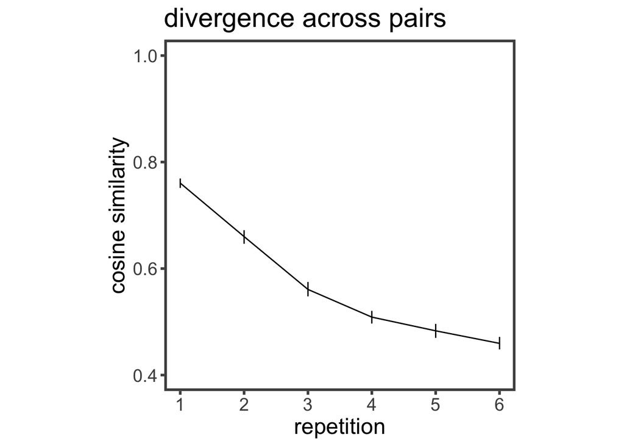

```r
true_lmer.across %>%
  group_by(dim1, repetition) %>%
  summarize(m = mean(sim, na.rm=T)) %>%
  group_by(repetition) %>%
  tidyboot_mean(m, na.rm=T) %>%
  ggplot(aes(x = repetition, y = empirical_stat)) +
    geom_errorbar(aes(ymin = ci_lower, ymax = ci_upper), width = 0) +
    geom_line()  +
    scale_x_continuous(breaks = c(1,2,3,4,5,6), labels = c(1,2,3,4,5,6)) +
    ylim(.4, 1) +
    ylab('cosine similarity') +
    ggtitle('divergence across pairs') +
    theme_few() +
    xlab('repetition') +
    guides(color = F, fill = F) +
    theme(aspect.ratio = 1, legend.position = c(0.5, 0.8), text = element_text(size=18),
          element_line(size=1), element_rect(size=2, color="#00000"))
```

```r
ggsave('../../writing/figs/divergence_mean.pdf', height = 10, width = 10, units = 'cm', useDingbats = F)
```

# Other figures

## Fig. 6: tsne visualizations

```r
tsne <- read_csv('../outputs/embeddings.csv') %>%
  left_join(d) %>%
  select(gameid, intendedName, repetitionNum, x_tsne, y_tsne, contents) %>%
  mutate(r = useful::cart2pol(x_tsne, y_tsne)$r,
         theta = useful::cart2pol(x_tsne, y_tsne)$theta) %>%
  group_by(gameid,  intendedName) %>%
  arrange(repetitionNum) %>%
  mutate(finalTheta = last(theta))
```

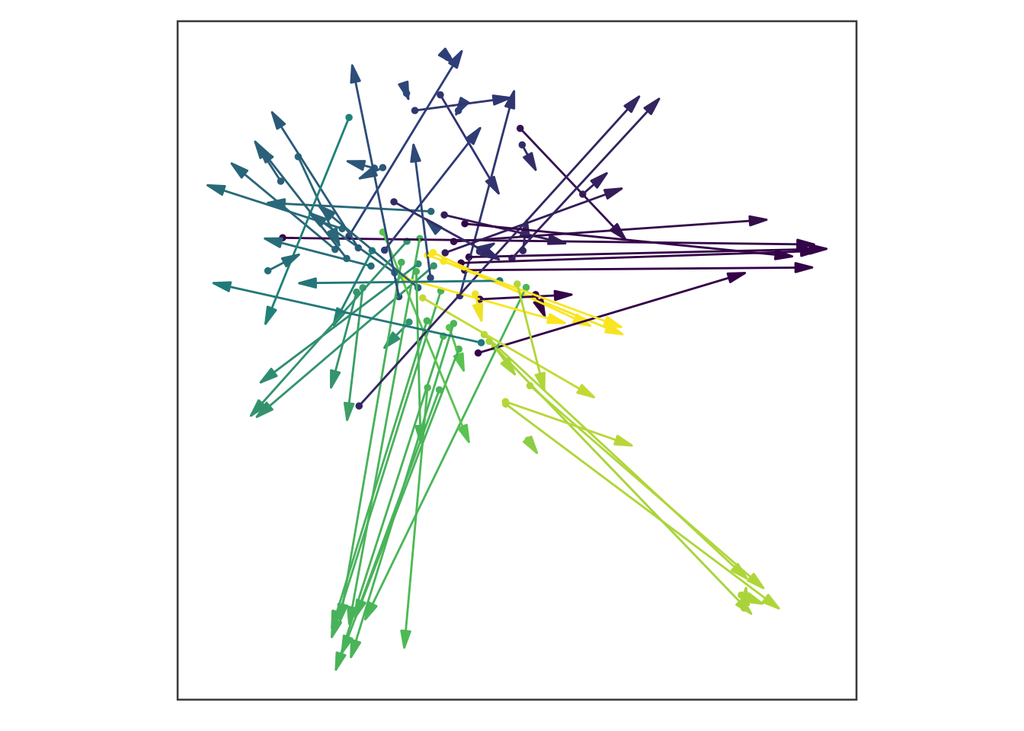

```r
tsne.toplot <- tsne %>%
  filter(intendedName == 'C') %>%
  filter(repetitionNum %in% c(1, 6)) %>%
  filter(!is.na(x_tsne)) %>%
  group_by(gameid) %>%
  mutate(next_x = lead(x_tsne) ,
         next_y = lead(y_tsne))

ggplot(tsne.toplot, aes(x = x_tsne, y = y_tsne, color = finalTheta)) +
    geom_point(data = subset(tsne.toplot, repetitionNum == 1),
               size = 1) +
    geom_segment(aes(xend = next_x, yend = next_y),
                 arrow.fill = NULL,
                 arrow = arrow(length = unit(0.30,"cm"),
                               angle = 15,
                               type = "closed")) +
    # uncomment this line to see text labels
    # geom_text(aes(label=contents), size = 1)+
    theme_few(20) +
    scale_shape_manual(values = c(21)) +
    scale_alpha_continuous(range = c(0.5, 1))+
    scale_color_gradientn(colours = viridis(5))+
      theme(axis.title=element_blank(),
        axis.text=element_blank(),
        axis.ticks=element_blank()) +
    labs(x = "", y = "") +
    guides(color = F, shape = F, alpha = F) +
    theme(aspect.ratio = 1)  #+
```

```r
# make it big to zoom in on text...
# ggsave(filename = '../../writing/figs/tsne-tangramC_enlarged.pdf',
#        width = 15, height = 15)

ggsave(filename = '../../writing/figs/tsne-tangramC.pdf',
       width = 5, height = 5)
```

## supplemental figure 11 showing all tangrams

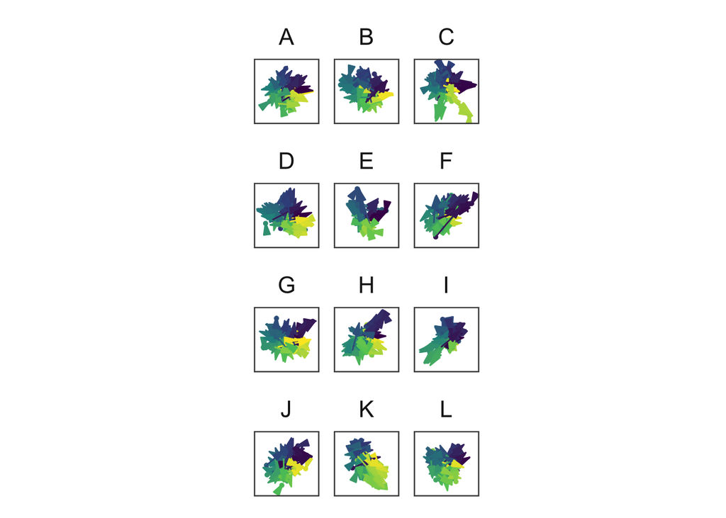

```r
tsne.all <- tsne %>%
  filter(repetitionNum %in% c(1, 6)) %>%
  filter(!is.na(x_tsne)) %>%
  group_by(gameid, intendedName) %>%
  mutate(next_x = lead(x_tsne) ,
         next_y = lead(y_tsne))

ggplot(tsne.all, aes(x = x_tsne, y = y_tsne, color = finalTheta)) +
    geom_point(data = subset(tsne.all, repetitionNum == 1),
               size = 1) +
    facet_wrap(~ intendedName, nrow = 4, ncol = 3) +
    geom_segment(aes(xend = next_x, yend = next_y), arrow.fill = NULL,
                 arrow = arrow(length=unit(0.30,"cm"), angle=15, type = "closed"), ) +
    # uncomment to see text labels
    # geom_text(aes(label=contents), size = 1)+
    theme_few(20) +
    scale_shape_manual(values = c(21)) +
    scale_alpha_continuous(range = c(0.5, 1))+
    scale_color_gradientn(colours = viridis(5))+
      theme(axis.title=element_blank(),
        axis.text=element_blank(),
        axis.ticks=element_blank()) +
    labs(x = "", y = "") +
    guides(color = F, shape = F, alpha = F) +
    theme(aspect.ratio = 1)
```

```r
ggsave(filename = '../../writing/figs/tsne-alltangrams.pdf',
       width = 15, height = 15)
```

## Appendix A: Discrete analyses

How much is within-game similarity disrupted by scrambling utterances across games?

Calculate entropy under permutation tests.

Note that we explicitly do *not* normalize entropies, as this removes the contribution of a bigger vocabulary (as we would expect)

Note: this is inefficient and takes a long time to run…

```r
getCounts <- function(contents) {
  corpus <- Corpus(VectorSource(paste(contents, collapse = " ")))
  return(colSums(as.matrix(DocumentTermMatrix(corpus, control = list(
    removePunctuation = TRUE, stopwords = TRUE, stemming = TRUE)))))
}

getCI <- function(vector) {
  l = length(vector)
  upper95 = ceiling(l*0.975)
  lower95 = floor(l*0.025)
  return(data.frame(list(ci_lower = sort(vector)[lower95],
                         ci_upper = sort(vector)[upper95],
                         empirical_stat = mean(sort(vector)))))
}

permutationTest <- function(d, sample_id) {
  # scramble across games within each repetition/tangram
  permuted = d %>%
    group_by(repetitionNum, intendedName) %>%
    mutate(permutation = sample(contents)) %>%
    group_by(gameid, intendedName) %>%
    summarize(rawEntropy = entropy(getCounts(permutation)),
              l = length(getCounts(permutation)),
            normedEntropy = rawEntropy/log(l)) %>%
    group_by(intendedName) %>%
    summarize(meanEnt = mean(rawEntropy)) %>%
    mutate(sample_id = sample_id)
  return(permuted)
}

permutations <- map_dfr(seq_len(100), ~permutationTest(d, .x)) %>%
  group_by(intendedName) %>%
  do(., getCI(.$meanEnt)) %>% mutate(sample_id = 'permuted')

trueEntropy <- d %>%
  group_by(gameid, intendedName) %>%
  summarize(rawEntropy = entropy(getCounts(contents)), l = length(getCounts(contents)),
            normedEntropy = rawEntropy/log(l)) %>%
  group_by(intendedName) %>%
  tidyboot_mean(rawEntropy, na.rm = T) %>%
  mutate(sample_id = 'empirical') %>%
  select(intendedName, ci_lower,ci_upper, empirical_stat, sample_id)
discrete.out <- bind_rows(permutations, trueEntropy)
```

Plotted

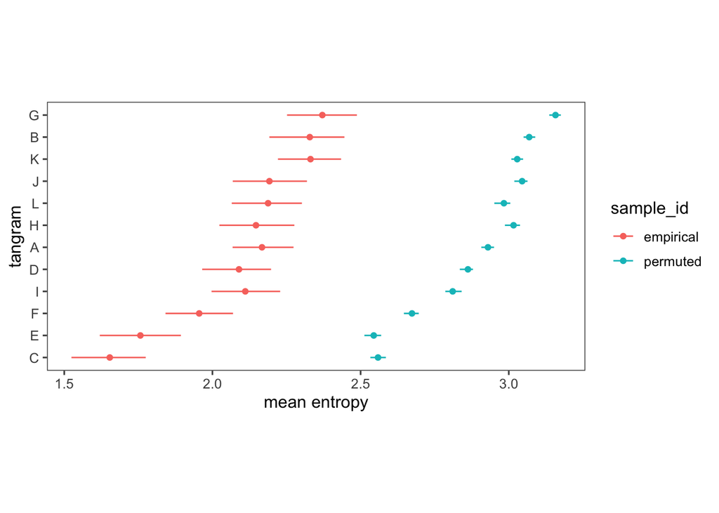

```r
ggplot(discrete.out, aes(x = empirical_stat, y = fct_reorder(factor(intendedName), empirical_stat),
                         color = sample_id)) +
  geom_point() +
  geom_errorbarh(aes(xmax = ci_upper, xmin = ci_lower), height = 0) +
  theme_few() +
  ylab('tangram') +
  xlab('mean entropy') +
  theme(aspect.ratio = 1/2)
```

```r
ggsave('../../writing/figs/permutedDiscrete_raw.pdf', height = 8, width = 16, units = 'cm', useDingbats = F)
```

## Appendix B: Additional baselines for evaluating divergence

```r
# workaround for reticulate python integration not working with knitr
# np <- import("numpy")
# for(name in raw_npy_names) {
#   mat = np$load(name)
#   saveRDS(paste0(name, '.RData'))
# }
```

```r
M_mat_scrambled <- read_csv('../outputs/meta_tangrams_embeddings_scrambled0.csv', col_types = "nccnlc", na = c('[nan]')) %>%
    mutate(feature_ind = X1 + 1, # Have to correct for R's (terrible) 1-indexing...
         gameID = gameid,
         target = intendedName,
         repetition = as.numeric(repetitionNum))
```

```r
raw_npy_names <- dir(path = '../outputs/', pattern = "feats_tangrams_embeddings_rawavg_scrambled[0-9]*.npy.RData", full.names = T)

raw_data <- map(raw_npy_names, ~ {
  print(.x)
  scrambled_mat <- readRDS(paste0(.x))
   M_mat_scrambled %>%
    group_by(target, repetition) %>%
    do(flatten_sim_matrix(get_sim_matrix(., scrambled_mat,
                                         method = 'cosine'), .$gameID)) %>%
    ungroup() %>%
    group_by(repetition) %>%
    summarize(m = mean(sim, na.rm = T)) %>%
    mutate(sample_id = .x)
  }) %>%
  reduce(rbind)               # read all csvs and combine into single data frame
```

[output not shown]

[output cut: 85 more lines]

```r
raw_data %>% group_by(repetition) %>% summarize(l = length(m), min = min(m), max = max(m)) %>% left_join(true_lmer.across %>% group_by(repetition) %>% summarize(empirical = mean(sim, na.rm = T)))
```

| repetition | l | min | max | empirical |
| --- | --- | --- | --- | --- |
| 1 | 100 | 0.7342245 | 0.7642017 | 0.7570748 |
| 2 | 100 | 0.6443710 | 0.6640949 | 0.6555570 |
| 3 | 100 | 0.5530101 | 0.5655169 | 0.5583080 |
| 4 | 100 | 0.4962756 | 0.5202110 | 0.5103790 |
| 5 | 100 | 0.4649367 | 0.4849924 | 0.4867908 |
| 6 | 100 | 0.4411812 | 0.4662903 | 0.4652924 |

It appears that similarity is slightly *higher* among utterances for the same tangram across different games than for different tangrams within the same game.

```
## geom_path: Each group consists of only one observation. Do you need to adjust
## the group aesthetic?
```

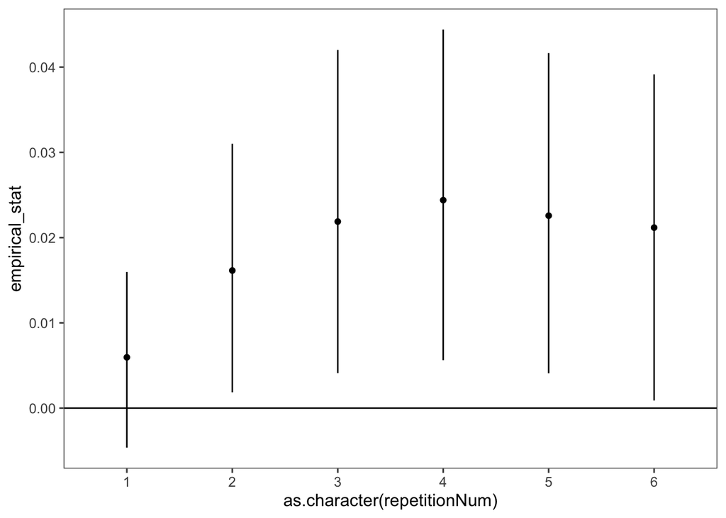

```r
acrossGames <- M_mat %>%
    group_by(target, repetitionNum) %>%
    do(flatten_sim_matrix(get_sim_matrix(., F_mat, method = 'cosine'),
                          .$gameid)) %>%
    filter(dim1 != dim2) %>%
  rename(gameid = dim1) %>%
    group_by(repetitionNum,gameid) %>%
  summarize(empirical_stat = mean(sim, na.rm = T)) %>% mutate(source ='across')

diffTangramWithinGames <- M_mat %>%
  group_by(gameid, repetitionNum) %>%
  do(flatten_sim_matrix(get_sim_matrix(., F_mat, method = 'cosine'),
                        .$target)) %>%
  summarize(empirical_stat = mean(sim, na.rm = T)) %>%
  filter(!is.na(empirical_stat)) %>%
  mutate(source = 'across tangrams in game')

bind_rows(acrossGames,diffTangramWithinGames) %>%
  spread(source, empirical_stat) %>%
  mutate(diff = across - `across tangrams in game`) %>%
  group_by(repetitionNum) %>%
  tidyboot_mean(diff, na.rm = T) %>%
  ggplot(aes(x = as.character(repetitionNum), y = empirical_stat)) +
    geom_line() +
  geom_point() +
    geom_errorbar(aes(ymin = ci_lower, ymax = ci_upper), width = 0) +
    geom_hline(yintercept = 0) +
    theme_few()
```

```r
unchanging_model <- lmer(diff ~ (1 |gameid), data = bind_rows(acrossGames,diffTangramWithinGames) %>%
  spread(source, empirical_stat) %>%
  mutate(diff = across - `across tangrams in game`))
mod2 <- lmer(diff ~ repetitionNum + (1 |gameid), data = bind_rows(acrossGames,diffTangramWithinGames) %>%
  spread(source, empirical_stat) %>%
  mutate(diff = across - `across tangrams in game`))
full_model <- lmer(diff ~ poly(repetitionNum,2) + (1 + repetitionNum|gameid), data = bind_rows(acrossGames,diffTangramWithinGames) %>%
  spread(source, empirical_stat) %>%
  mutate(diff = across - `across tangrams in game`))

anova(unchanging_model, mod2, full_model)
```

```
## refitting model(s) with ML (instead of REML)
```

|  | npar | AIC | BIC | logLik | deviance | Chisq | Df | Pr(>Chisq) |
| --- | --- | --- | --- | --- | --- | --- | --- | --- |
| unchanging_model | 3 | -1463.943 | -1451.348 | 734.9717 | -1469.943 | NA | NA | NA |
| mod2 | 4 | -1467.974 | -1451.180 | 737.9871 | -1475.974 | 6.030864 | 1 | 1.405785e-02 |
| full_model | 7 | -1643.611 | -1614.222 | 828.8056 | -1657.611 | 181.637046 | 3 | 3.907784e-39 |

```r
summary(full_model)
```

```
## Linear mixed model fit by REML. t-tests use Satterthwaite's method [
## lmerModLmerTest]
## Formula: diff ~ poly(repetitionNum, 2) + (1 + repetitionNum | gameid)
##    Data: bind_rows(acrossGames, diffTangramWithinGames) %>% spread(source,
##     empirical_stat) %>% mutate(diff = across - `across tangrams in game`)
##
## REML criterion at convergence: -1640.8
##
## Scaled residuals:
##      Min       1Q   Median       3Q      Max
## -2.95601 -0.48747 -0.02403  0.55892  2.68750
##
## Random effects:
##  Groups   Name          Variance  Std.Dev. Corr
##  gameid   (Intercept)   0.0027369 0.05232
##           repetitionNum 0.0002684 0.01638  -0.23
##  Residual               0.0009050 0.03008
## Number of obs: 492, groups:  gameid, 82
##
## Fixed effects:
##                           Estimate Std. Error         df t value Pr(>|t|)
## (Intercept)               0.018686   0.007665  80.999895   2.438  0.01697 *
## poly(repetitionNum, 2)1   0.106574   0.075298  81.000023   1.415  0.16080
## poly(repetitionNum, 2)2  -0.087642   0.030266 327.000063  -2.896  0.00404 **
## ---
## Signif. codes:  0 '***' 0.001 '**' 0.01 '*' 0.05 '.' 0.1 ' ' 1
##
## Correlation of Fixed Effects:
##             (Intr) p(N,2)1
## ply(rpN,2)1 0.600
## ply(rpN,2)2 0.000  0.000
```

```r
bind_rows(acrossGames,diffTangramWithinGames) %>%
  spread(source, empirical_stat) %>%
  mutate(diff = across - `across tangrams in game`) %>%
  group_by(repetitionNum) %>%
  summarize(diff = mean(diff, na.rm = T),
            across = mean(across, na.rm = T),
            `across tangrams in game` = mean(`across tangrams in game`, na.rm = T))
```

| repetitionNum | diff | across | across tangrams in game |
| --- | --- | --- | --- |
| 1 | 0.005957995 | 0.7605248 | 0.7523020 |
| 2 | 0.016140597 | 0.6600226 | 0.6432227 |
| 3 | 0.021880985 | 0.5608502 | 0.5394195 |
| 4 | 0.024395113 | 0.5088521 | 0.4851600 |
| 5 | 0.022570892 | 0.4831231 | 0.4616866 |
| 6 | 0.021171437 | 0.4595377 | 0.4396266 |